# Lake Mendota Freezing and Thawing

Bret Larget

Professor Jessi Cisewski Kehe contributed to these lecture notes.

## Overview

- Read the [chapter on Lake Mendota](https://bookdown.org/bret_larget/stat-240-case-studies/madison-lakes.html) from the Course Notes and Case Studies for background.

### Preliminaries

- For you to be able to run the code in this file, you need to put files in proper locations and set the working directory.
- Let `COURSE` represent your course directory.
1. Affirm that the directories `COURSE/lecture/` and `COURSE/lecture/unit2/` exist.
2. Download the file `04-lake-mendota.Rmd` into the `unit2` sub-folder.
3. Affirm that the file `lake-mendota-winters-2021.csv` is in the `COURSE/data` folder.

## Lake Mendota Graphs – days frozen vs. time

- We wish to create a graph to examine the relationship between the duration which Lake Mendota is frozen versus time
- We may expect there to be a decrease over time as a result of global warming causing the average temperature in Madison to be trending warmer in the winter.

## Read Data: Lake Mendota

- If you have trouble reading in the data, make sure your working directory matches the location of the R Markdown file
- Your current working directory can be determined by running `getwd()` in the console.

```r
mendota = read_csv("../../data/lake-mendota-winters-2021.csv")
spec(mendota)
```

## What to do with the data?

- We have now loaded our data, what sorts of questions might we want to address using them?
- Let’s explore a few questions.

## Question 1

> How do the total number of days that Lake Mendota is closed with ice vary over time?
- That is, do we see any trend across time? Do the total number of days that Lake Mendota is closed with ice increase or decrease?
- With any data analysis, it is important to explore your data. Visualization can help to reveal interesting features or possible issues.
- We will use `ggplot()` to create a scatter plot of the data of the `duration` variable plot by `year1`. Then we will add a smooth line to reveal any pattern across time.

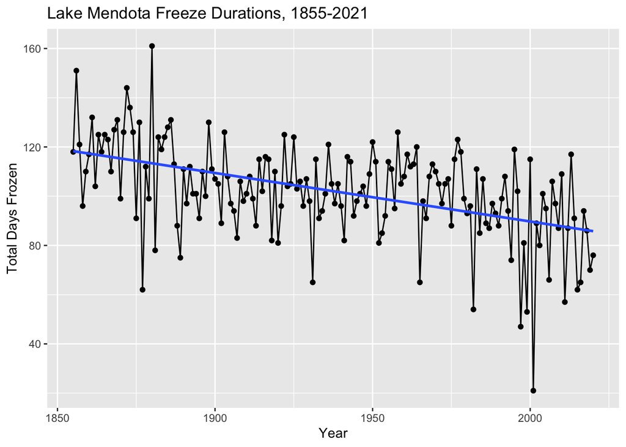

```r
## first argument to ggplot is a data frame
## the second argument is a mapping of the aesthetics
ggplot(data = mendota, mapping = aes(x=year1, y=duration)) +
  ## add points to the plot with the x and y aesthetics
  geom_point() +
  ## draw lines between consecutive points
  geom_line() +
  ## add a smooth trend line
  geom_smooth(se=FALSE, method = "lm") +
  ## change the label on the x axis
  xlab("Year") +
  ## change the label on the y axis
  ylab("Total Days Frozen") +
  ## add a title
  ggtitle("Lake Mendota Freeze Durations, 1855-2021")
```

## Lake Mendota Graphs – distribution of days closed by ice

## Question 2

> What does the distribution of the number of days that Lake Mendota is closed by ice look like?
- Each variable of our data set has its own column.
- Variables have different values and you can roughly think of the distribution as telling us the frequency of observations that have a value.
  - (We’ll get a bit more technical about this later.)
- Histograms are a common way to display distributions of numerical data.

### Histogram with `geom_histogram()`

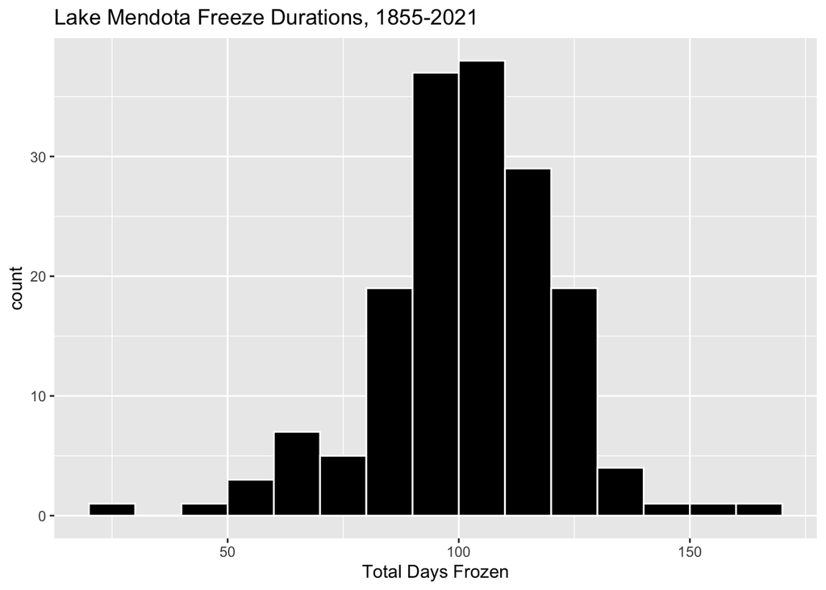

```r
ggplot(mendota, aes(x=duration)) +
  geom_histogram(binwidth = 10,fill = "black", color = "white", center = 65) +
  xlab("Total Days Frozen") +
  ggtitle("Lake Mendota Freeze Durations, 1855-2021")
```

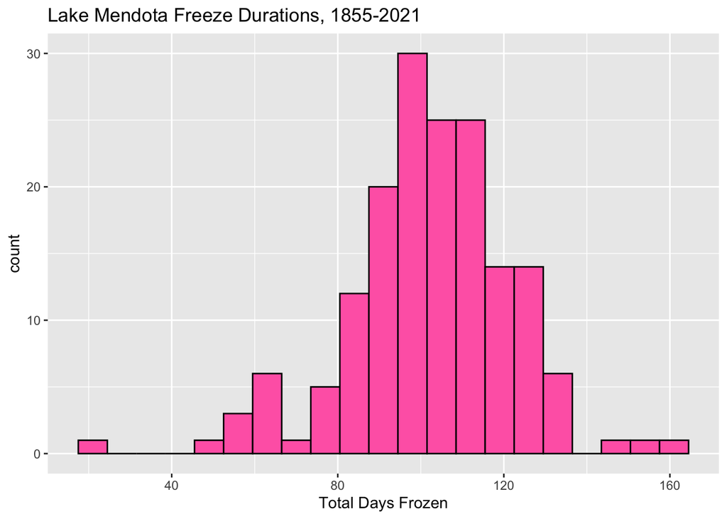

```r
ggplot(mendota, aes(x=duration)) +
  geom_histogram(center=70, binwidth=7,
                 fill='hotpink', color='black') +
  xlab("Total Days Frozen") +
  ggtitle("Lake Mendota Freeze Durations, 1855-2021")
```

#### A histogram with too few bins

- Selecting appropriate settings for the bins is not easy and it can dramatically affect the appearance of the histogram.
- The histogram below has too few bins (the bins were set to be too wide) and we cannot evaluate the shape of the distribution because it has been over-summarized.

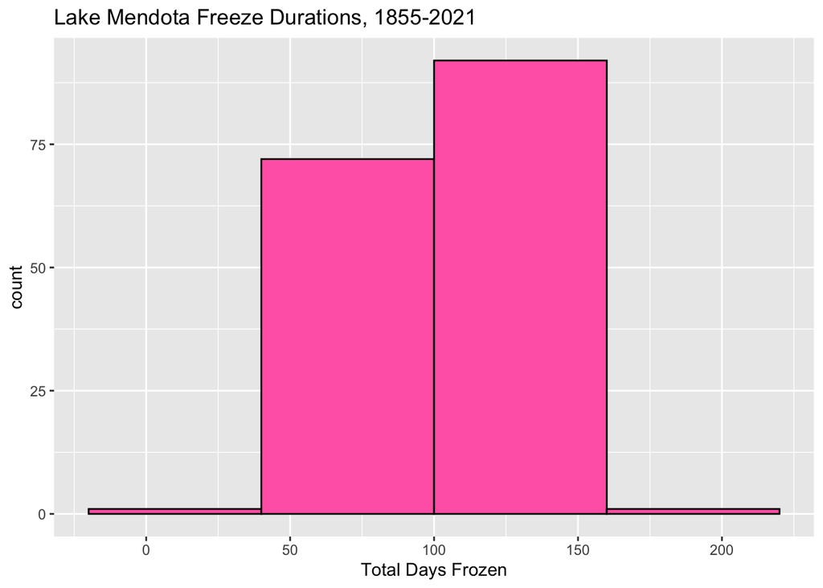

```r
ggplot(mendota, aes(x=duration)) +
  geom_histogram(center=70, binwidth=60, fill='hotpink',
                 color='black') +
  xlab("Total Days Frozen") +
  ggtitle("Lake Mendota Freeze Durations, 1855-2021")
```

#### A histogram with too many bins

- We can also error in the direction of too many bins!
- In the histogram below, the bin width is too small revealing many spikes.
- Again we cannot evaluate the shape of the distribution because there is too much detail.

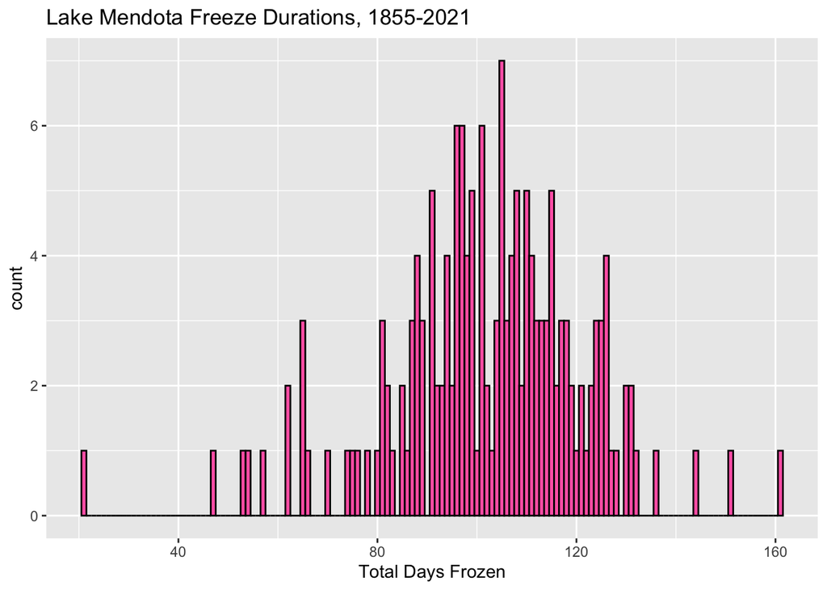

```r
ggplot(mendota, aes(x=duration)) +
  geom_histogram(center=70, binwidth=1,
                 fill='hotpink', color='black') +
  xlab("Total Days Frozen") +
  ggtitle("Lake Mendota Freeze Durations, 1855-2021")
```

### Density Plot with `geom_density()`

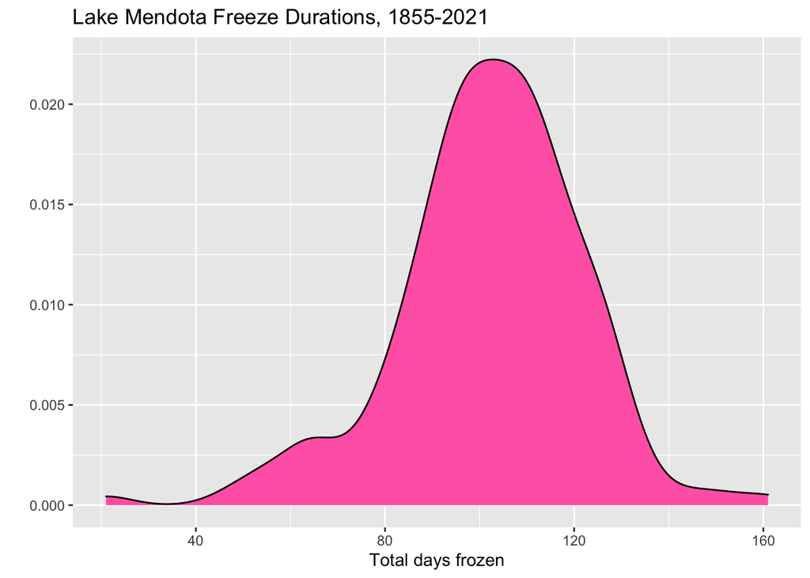

```r
ggplot(mendota) +
  geom_density(aes(x=duration),
               fill="hotpink",
               color="black") +
  xlab("Total days frozen") +
  ylab("") +
  ggtitle("Lake Mendota Freeze Durations, 1855-2021")
```

- A density plot may be thought of as an average of a lot of histograms
- It avoids the issues of picking bin widths and boundaries (but there is a smoothing parameter that needs to be specified)
- The total area under the curve is one (it is a density!)

### Boxplot with `geom_boxplot()`

- A boxplot requires a categorical variable for the `x` argument and the quantitative variable is `y`.
- Prior to making the plot, we add a categorical variable with a nice decade label.

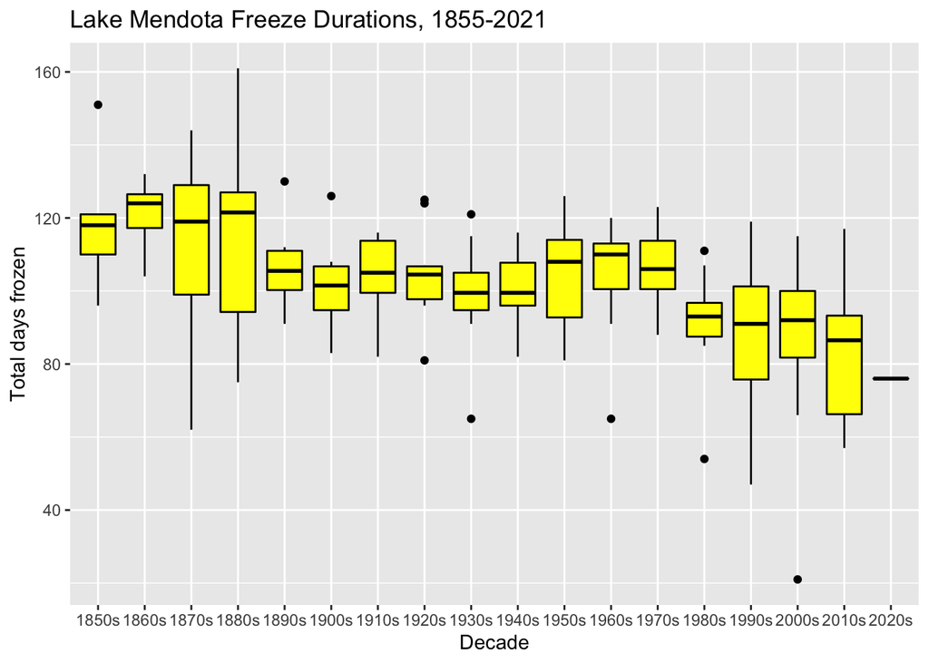

```r
## add the decade label in the variable decade_label
mendota = mendota %>% ## pai
  mutate(decade_label = str_c(decade, "s")) ## adding 's' to the end ot year

ggplot(mendota) +
  geom_boxplot(aes(x=decade_label, y=duration),
               fill="yellow",
               color="black") +
  ylab("Total days frozen") +
  xlab("Decade") +
  ggtitle("Lake Mendota Freeze Durations, 1855-2021")
```

- This boxplot gives a summary of the distribution of the total number of days that Lake Mendota is closed with ice for each decade.